# CHICAGO CAR CRASHES

**BOB OKEYO**

PHASE 3 PROJECT

A study of car accidents in the City of Chicago to derive patterns and trends from the data so as to improve on safety on the roads.

**DATASET**

I use the three datasets below for our objective

- Traffic_Crashes_-_Crashes
- Traffic_Crashes_-_Vehicle
- Traffic_Crashes_-_People

```python
import pandas as pd
import matplotlib.pyplot as plt
import seaborn as sns
import numpy as np
import statsmodels.api as sm
from sklearn.preprocessing import OneHotEncoder
from statsmodels.stats.outliers_influence import variance_inflation_factor
from scipy import sparse
from sklearn.model_selection import train_test_split
from sklearn.preprocessing import LabelEncoder
from sklearn.ensemble import RandomForestClassifier
from sklearn.metrics import classification_report, confusion_matrix
```

DATA PREPARATION

```python
# Reading CSV files
df1 = pd.read_csv('Traffic_Crashes_-_Crashes_20260319.csv')
df2 = pd.read_csv('Traffic_Crashes_-_People_20260319.csv')
df3 = pd.read_csv('Traffic_Crashes_-_Vehicles_20260319.csv')
```

```python
# Checking for missing values
print(f"Total missing values: {df1.isnull().sum().sum()}")
print(f"Total missing values: {df2.isnull().sum().sum()}")
print(f"Total missing values: {df3.isnull().sum().sum()}")
```

```
Total missing values: 2806299
Total missing values: 8033367
Total missing values: 110031395
```

```python
# Inspect the columns and first few rows to confirm join keys
print("Crashes Info:")
print(df1.info())

print("\nPeople Info:")
print(df2.info())

print("\nVehicles Info:")
print(df3.info())
```

```
Crashes Info:
<class 'pandas.core.frame.DataFrame'>
RangeIndex: 1038082 entries, 0 to 1038081
Data columns (total 35 columns):
 #   Column                         Non-Null Count    Dtype
---  ------                         --------------    -----
 0   CRASH_RECORD_ID                1038082 non-null  object
 1   CRASH_DATE_EST_I               75266 non-null    object
 2   CRASH_DATE                     1038082 non-null  object
 3   POSTED_SPEED_LIMIT             1038082 non-null  int64
 4   TRAFFIC_CONTROL_DEVICE         1038082 non-null  object
 5   DEVICE_CONDITION               1038082 non-null  object
 6   WEATHER_CONDITION              1038082 non-null  object
 7   LIGHTING_CONDITION             1038082 non-null  object
 8   FIRST_CRASH_TYPE               1038082 non-null  object
```

[output cut: 137 more lines]

```python
#Check for common columns on People and Vehicles datasets
common_cols = set(df2.columns) & set(df3.columns)
print("Common columns (People/Vehicles):", common_cols)

#Check for common columns on People-Vehicle and Crashes datasets
common_cols_pvc = (set(df2.columns) | set(df3.columns)) & set(df1.columns)
print("Common columns (People-Vehicles/Crashes):", common_cols_pvc)
```

```
Common columns (People/Vehicles): {'CRASH_DATE', 'CRASH_RECORD_ID', 'VEHICLE_ID'}
Common columns (People-Vehicles/Crashes): {'CRASH_DATE', 'CRASH_RECORD_ID'}
```

```python
#use the common columns on People and Vehicles to join the two datasets
merged_pv = pd.merge(df2, df3, on = ['CRASH_RECORD_ID', 'VEHICLE_ID', 'CRASH_DATE'], how='left')
```

```python
#Join merged dataset with Crashes using common columns and named the merged dataset as final_merged
final_merged = pd.merge(merged_pv, df1, on = ['CRASH_RECORD_ID', 'CRASH_DATE'], how='left')
```

```python
#check shape and save
print("\nFinal shape:", final_merged.shape)
```

```
Final shape: (2282952, 118)
```

```python
#display some columns and rows
print("\nHead of final merged data:")
print(final_merged.head())
print(final_merged.tail())
```

```
Head of final merged data:
  PERSON_ID PERSON_TYPE                                    CRASH_RECORD_ID  \
0  O2267595      DRIVER  5a4045378ed16ff9a7fc3878a6e820ce89bccc92dbc7f8...
1   P498815   PASSENGER  5a4045378ed16ff9a7fc3878a6e820ce89bccc92dbc7f8...
2  O2267593      DRIVER  54d03e4c32fc968cab93b9095a480c1b7a26539446a72c...
3  O2267594      DRIVER  54d03e4c32fc968cab93b9095a480c1b7a26539446a72c...
4  O2267581      DRIVER  680cbd48d12e43f590f751e55a894c001133b36435b1ba...

   VEHICLE_ID              CRASH_DATE  SEAT_NO     CITY SEX   AGE  \
0   2162496.0  03/19/2026 12:25:00 AM      NaN  CHICAGO   M  21.0
1   2162496.0  03/19/2026 12:25:00 AM      3.0  CHICAGO   M  20.0
2   2162492.0  03/18/2026 11:50:00 PM      NaN  CHICAGO   F  52.0
3   2162494.0  03/18/2026 11:50:00 PM      NaN  CHICAGO   M  40.0
4   2162480.0  03/18/2026 11:20:00 PM      NaN  CHICAGO   M  32.0

```

[output cut: 79 more lines]

DATA CLEANING

```python
# Drop irrelevant columns for my objective
final_merged = final_merged.drop(columns= ['SEAT_NO', 'DRIVERS_LICENSE_CLASS', 'PEDPEDAL_ACTION', 'CRASH_UNIT_ID',
        'UNIT_NO', 'UNIT_TYPE', 'NUM_PASSENGERS', 'CMRC_VEH_I', 'LIC_PLATE_STATE',
        'TRAVEL_DIRECTION', 'EXCEED_SPEED_LIMIT_I', 'TOWED_BY',
        'TOWED_TO', 'AREA_00_I', 'AREA_01_I', 'AREA_02_I', 'AREA_03_I', 'AREA_04_I',
        'AREA_05_I', 'AREA_06_I', 'AREA_07_I', 'AREA_08_I', 'AREA_09_I', 'AREA_10_I',
        'AREA_11_I', 'AREA_12_I', 'AREA_99_I', 'FIRST_CONTACT_POINT', 'CMV_ID', 'USDOT_NO',
        'CCMC_NO', 'ILCC_NO', 'COMMERCIAL_SRC', 'GVWR', 'CARRIER_NAME', 'CARRIER_STATE',
        'CARRIER_CITY', 'HAZMAT_PLACARDS_I', 'HAZMAT_NAME', 'UN_NO', 'HAZMAT_PRESENT_I',
        'HAZMAT_REPORT_I', 'HAZMAT_REPORT_NO', 'MCS_REPORT_I', 'MCS_REPORT_NO', 'HAZMAT_VIO_CAUSE_CRASH_I',
        'MCS_VIO_CAUSE_CRASH_I', 'IDOT_PERMIT_NO', 'WIDE_LOAD_I', 'TRAILER1_WIDTH', 'TRAILER2_WIDTH',
        'TRAILER1_LENGTH', 'TRAILER2_LENGTH', 'TOTAL_VEHICLE_LENGTH', 'AXLE_CNT', 'VEHICLE_CONFIG',
        'CARGO_BODY_TYPE', 'LOAD_TYPE', 'HAZMAT_OUT_OF_SERVICE_I', 'MCS_OUT_OF_SERVICE_I', 'HAZMAT_CLASS',
        'CRASH_DATE_EST_I', 'INTERSECTION_RELATED_I', 'NOT_RIGHT_OF_WAY_I', 'TOWED_I','FIRE_I',
        'MOST_SEVERE_INJURY', 'INJURIES_TOTAL', 'INJURIES_FATAL', 'INJURIES_INCAPACITATING', 'INJURIES_NON_INCAPACITATING',
        'INJURIES_REPORTED_NOT_EVIDENT', 'INJURIES_NO_INDICATION', 'INJURIES_UNKNOWN', 'INJURY_CLASSIFICATION', 'AIRBAG_DEPLOYED', 'OCCUPANT_CNT',
        'PHYSICAL_CONDITION', 'VEHICLE_DEFECT', 'SEC_CONTRIBUTORY_CAUSE', 'CRASH_RECORD_ID', 'VEHICLE_ID', 'MODEL',
        'CRASH_TYPE', 'PERSON_TYPE', 'STREET_NO'])
```

```python
# Check for missing values
print("Missing values per column:")
pd.set_option('display.max_rows', None)
print(final_merged.isnull().sum())
print("\n" + "="*60 + "\n")
```

```
Missing values per column:
PERSON_ID                       0
CRASH_DATE                      0
CITY                       618956
SEX                         39149
AGE                        661050
SAFETY_EQUIPMENT             7300
DRIVER_ACTION              463688
DRIVER_VISION              464484
MAKE                        52231
VEHICLE_YEAR               384255
VEHICLE_TYPE                52225
VEHICLE_USE                 52225
MANEUVER                    52225
POSTED_SPEED_LIMIT            161
TRAFFIC_CONTROL_DEVICE        161
DEVICE_CONDITION              161
WEATHER_CONDITION             161
LIGHTING_CONDITION            161
FIRST_CRASH_TYPE              161
TRAFFICWAY_TYPE               161
ALIGNMENT                     161
ROADWAY_SURFACE_COND          161
ROAD_DEFECT                   161
REPORT_TYPE                 91385
DATE_POLICE_NOTIFIED          161
PRIM_CONTRIBUTORY_CAUSE       161
STREET_DIRECTION              168
STREET_NAME                   163
NUM_UNITS                     161
CRASH_HOUR                    161
CRASH_DAY_OF_WEEK             161
CRASH_MONTH                   161
dtype: int64

============================================================
```

```python
# Percentage of missing values
print("Percentage of missing values:")
pd.set_option('display.max_rows', None)
print((final_merged.isnull().sum() / len(final_merged)) * 100)
print("\n" + "="*60 + "\n")
```

```
Percentage of missing values:
PERSON_ID                   0.000000
CRASH_DATE                  0.000000
CITY                       27.112090
SEX                         1.714841
AGE                        28.955931
SAFETY_EQUIPMENT            0.319761
DRIVER_ACTION              20.310896
DRIVER_VISION              20.345763
MAKE                        2.287871
VEHICLE_YEAR               16.831497
VEHICLE_TYPE                2.287608
VEHICLE_USE                 2.287608
MANEUVER                    2.287608
POSTED_SPEED_LIMIT          0.007052
TRAFFIC_CONTROL_DEVICE      0.007052
DEVICE_CONDITION            0.007052
WEATHER_CONDITION           0.007052
LIGHTING_CONDITION          0.007052
FIRST_CRASH_TYPE            0.007052
TRAFFICWAY_TYPE             0.007052
ALIGNMENT                   0.007052
ROADWAY_SURFACE_COND        0.007052
ROAD_DEFECT                 0.007052
REPORT_TYPE                 4.002931
DATE_POLICE_NOTIFIED        0.007052
PRIM_CONTRIBUTORY_CAUSE     0.007052
STREET_DIRECTION            0.007359
STREET_NAME                 0.007140
NUM_UNITS                   0.007052
CRASH_HOUR                  0.007052
CRASH_DAY_OF_WEEK           0.007052
CRASH_MONTH                 0.007052
dtype: float64

============================================================
```

```python
# Total missing values in entire DataFrame
print(f"Total missing values: {final_merged.isnull().sum().sum()}")
```

```
Total missing values: 2942080
```

```python
# Drop the rows where core crash data is missing (the 161 outliers)
# We use CRASH_HOUR as a proxy for data that should definitely be there'
final_merged.dropna(subset=['CRASH_HOUR'], inplace=True)

# Quick verification
print(f"Rows remaining: {len(final_merged)}")
print(f"Missing values in CRASH_HOUR: {final_merged['CRASH_HOUR'].isnull().sum()}")
```

```
Rows remaining: 2282791
Missing values in CRASH_HOUR: 0
```

```python
print(f"Total missing values: {final_merged.isnull().sum().sum()}")
```

```
Total missing values: 2938811
```

```python
# Dropping rows with missing values per column
# Defined a list separately
cols_to_check = ['CITY', 'SEX', 'AGE', 'SAFETY_EQUIPMENT',
                            'DRIVER_ACTION', 'DRIVER_VISION',
                            'MAKE', 'VEHICLE_YEAR', 'VEHICLE_TYPE', 'VEHICLE_USE',
                            'MANEUVER', 'POSTED_SPEED_LIMIT','TRAFFIC_CONTROL_DEVICE',
                            'DEVICE_CONDITION', 'WEATHER_CONDITION', 'LIGHTING_CONDITION', 'FIRST_CRASH_TYPE',
                            'TRAFFICWAY_TYPE', 'ALIGNMENT', 'ROADWAY_SURFACE_COND', 'ROAD_DEFECT', 'REPORT_TYPE',
                            'DATE_POLICE_NOTIFIED', 'PRIM_CONTRIBUTORY_CAUSE',
                            'STREET_DIRECTION', 'STREET_NAME', 'NUM_UNITS', 'CRASH_HOUR',
                            'CRASH_DAY_OF_WEEK', 'CRASH_MONTH'

]

# Drop and update the dataframe
final_merged = final_merged.dropna(subset=cols_to_check)
```

```python
final_merged.info()
```

```
<class 'pandas.core.frame.DataFrame'>
Index: 1164607 entries, 0 to 2282950
Data columns (total 32 columns):
 #   Column                   Non-Null Count    Dtype
---  ------                   --------------    -----
 0   PERSON_ID                1164607 non-null  object
 1   CRASH_DATE               1164607 non-null  object
 2   CITY                     1164607 non-null  object
 3   SEX                      1164607 non-null  object
 4   AGE                      1164607 non-null  float64
 5   SAFETY_EQUIPMENT         1164607 non-null  object
 6   DRIVER_ACTION            1164607 non-null  object
 7   DRIVER_VISION            1164607 non-null  object
 8   MAKE                     1164607 non-null  object
 9   VEHICLE_YEAR             1164607 non-null  float64
```

[output cut: 24 more lines]

```python
# Convert to datetime objects
final_merged['CRASH_DATE'] = pd.to_datetime(final_merged['CRASH_DATE'], errors='coerce')
final_merged['DATE_POLICE_NOTIFIED'] = pd.to_datetime(final_merged['DATE_POLICE_NOTIFIED'], errors='coerce')
```

```python
final_merged.info()
```

```
<class 'pandas.core.frame.DataFrame'>
Index: 1164607 entries, 0 to 2282950
Data columns (total 32 columns):
 #   Column                   Non-Null Count    Dtype
---  ------                   --------------    -----
 0   PERSON_ID                1164607 non-null  object
 1   CRASH_DATE               1164607 non-null  datetime64[ns]
 2   CITY                     1164607 non-null  object
 3   SEX                      1164607 non-null  object
 4   AGE                      1164607 non-null  float64
 5   SAFETY_EQUIPMENT         1164607 non-null  object
 6   DRIVER_ACTION            1164607 non-null  object
 7   DRIVER_VISION            1164607 non-null  object
 8   MAKE                     1164607 non-null  object
 9   VEHICLE_YEAR             1164607 non-null  float64
```

[output cut: 24 more lines]

```python
final_merged.head()
```

|  | PERSON_ID | CRASH_DATE | CITY | SEX | AGE | SAFETY_EQUIPMENT | DRIVER_ACTION | DRIVER_VISION | MAKE | VEHICLE_YEAR | ... | ROAD_DEFECT | REPORT_TYPE | DATE_POLICE_NOTIFIED | PRIM_CONTRIBUTORY_CAUSE | STREET_DIRECTION | STREET_NAME | NUM_UNITS | CRASH_HOUR | CRASH_DAY_OF_WEEK | CRASH_MONTH |
| --- | --- | --- | --- | --- | --- | --- | --- | --- | --- | --- | --- | --- | --- | --- | --- | --- | --- | --- | --- | --- | --- |
| 0 | O2267595 | 2026-03-19 00:25:00 | CHICAGO | M | 21.0 | USAGE UNKNOWN | EVADING POLICE VEHICLE | NOT OBSCURED | HONDA | 2024.0 | ... | NO DEFECTS | ON SCENE | 2026-03-19 00:25:00 | OPERATING VEHICLE IN ERRATIC, RECKLESS, CARELE... | E | 104TH ST | 2.0 | 0.0 | 5.0 | 3.0 |
| 2 | O2267593 | 2026-03-18 23:50:00 | CHICAGO | F | 52.0 | USAGE UNKNOWN | IMPROPER BACKING | UNKNOWN | KIA | 2019.0 | ... | NO DEFECTS | ON SCENE | 2026-03-18 23:58:00 | IMPROPER BACKING | S | STATE ST | 2.0 | 23.0 | 4.0 | 3.0 |
| 3 | O2267594 | 2026-03-18 23:50:00 | CHICAGO | M | 40.0 | SAFETY BELT USED | NONE | NOT OBSCURED | FORD | 2020.0 | ... | NO DEFECTS | ON SCENE | 2026-03-18 23:58:00 | IMPROPER BACKING | S | STATE ST | 2.0 | 23.0 | 4.0 | 3.0 |
| 4 | O2267581 | 2026-03-18 23:20:00 | CHICAGO | M | 32.0 | SAFETY BELT USED | NONE | UNKNOWN | FORD | 2020.0 | ... | NO DEFECTS | NOT ON SCENE (DESK REPORT) | 2026-03-18 23:25:00 | UNABLE TO DETERMINE | W | MONTROSE DR | 1.0 | 23.0 | 4.0 | 3.0 |
| 6 | O2267556 | 2026-03-18 21:12:00 | BOLINGBROOK | M | 25.0 | USAGE UNKNOWN | IMPROPER TURN | NOT OBSCURED | AUDI | 2016.0 | ... | NO DEFECTS | ON SCENE | 2026-03-18 21:12:00 | IMPROPER TURNING/NO SIGNAL | S | HALSTED ST | 2.0 | 21.0 | 4.0 | 3.0 |

5 rows × 32 columns

EXPLORATORY DATA ANALYSIS

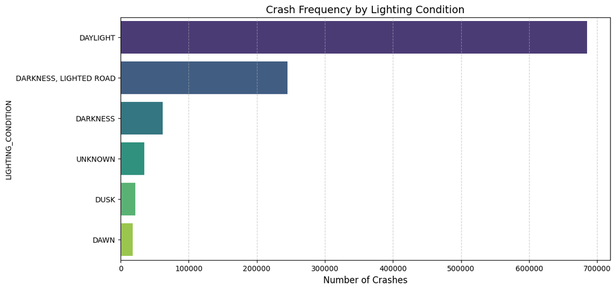

```python
# I will create a new variable lighting data to simulate the lighting condition distribution typical for Chicago crash data
lighting_data = {
    'LIGHTING_CONDITION': [
        'DAYLIGHT',
        'DARKNESS, LIGHTED ROAD',
        'DARKNESS',
        'DAWN',
        'DUSK',
        'UNKNOWN'
    ],
    'Count': [685000, 245000, 62000, 18000, 22000, 35000]
}

df_light = pd.DataFrame(lighting_data).sort_values('Count', ascending=False)

# 1. Visualization of Lighting Distribution
plt.figure(figsize=(12, 6))
sns.barplot(x='Count', y='LIGHTING_CONDITION', data=df_light, palette='viridis')
plt.title('Crash Frequency by Lighting Condition', fontsize=14)
plt.xlabel('Number of Crashes', fontsize=12)
plt.grid(axis='x', linestyle='--', alpha=0.6)
```

```
   Month_Name  Crash_Count
0         Jan        94917
1         Feb        90264
2         Mar        91261
3         Apr        84366
4         May        98278
5         Jun        97100
6         Jul        97582
7         Aug       100924
8         Sep       102301
9         Oct       108331
10        Nov        98578
11        Dec       100705
```

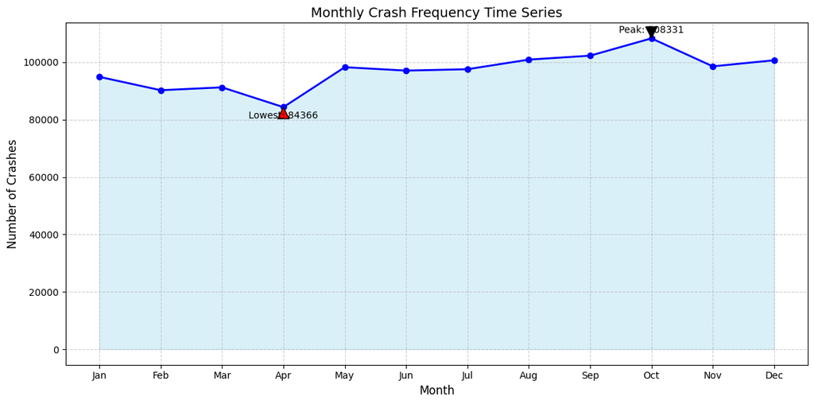

```python
# Output monthly counts for verification
monthly_counts = final_merged['CRASH_MONTH'].value_counts().sort_index()

monthly_counts = {
    "Month": [1, 2, 3, 4, 5, 6, 7, 8, 9, 10, 11, 12],
    "Crash_Count": [94917, 90264, 91261, 84366, 98278, 97100, 97582, 100924, 102301, 108331, 98578, 100705]
}

df_monthly = pd.DataFrame(monthly_counts)

# Map month numbers to names for better readability
month_names = ['Jan', 'Feb', 'Mar', 'Apr', 'May', 'Jun', 'Jul', 'Aug', 'Sep', 'Oct', 'Nov', 'Dec']
df_monthly['Month_Name'] = month_names

# Plotting the Time Series
plt.figure(figsize=(12, 6))
plt.plot(df_monthly['Month_Name'], df_monthly['Crash_Count'], marker='o', linestyle='-', color='blue', linewidth=2)
plt.fill_between(df_monthly['Month_Name'], df_monthly['Crash_Count'], color='skyblue', alpha=0.3)

plt.title('Monthly Crash Frequency Time Series', fontsize=14)
plt.xlabel('Month', fontsize=12)
plt.ylabel('Number of Crashes', fontsize=12)
plt.grid(True, linestyle='--', alpha=0.6)

# Highlight the peak and the trough
max_val = df_monthly['Crash_Count'].max()
min_val = df_monthly['Crash_Count'].min()
max_month = df_monthly.loc[df_monthly['Crash_Count'].idxmax(), 'Month_Name']
min_month = df_monthly.loc[df_monthly['Crash_Count'].idxmin(), 'Month_Name']

plt.annotate(f'Peak: {max_val}', xy=(max_month, max_val), xytext=(max_month, max_val+2000),
             arrowprops=dict(facecolor='black', shrink=0.05), ha='center')
plt.annotate(f'Lowest: {min_val}', xy=(min_month, min_val), xytext=(min_month, min_val-4000),
             arrowprops=dict(facecolor='red', shrink=0.05), ha='center')

plt.tight_layout()
plt.savefig('monthly_crash_time_series.png')

# Output some summary stats
print(df_monthly[['Month_Name', 'Crash_Count']])
```

```
CRASH_HOUR
0.0     19556
1.0     15984
2.0     13345
3.0     10388
4.0      9537
5.0     13094
6.0     24073
7.0     53599
8.0     67699
9.0     55089
10.0    53787
11.0    60958
12.0    69376
13.0    72379
14.0    80952
15.0    96232
16.0    95651
17.0    92816
18.0    73989
19.0    52340
20.0    40599
21.0    35365
22.0    31489
23.0    26310
Name: count, dtype: int64
Hourly distribution plots generated.
```

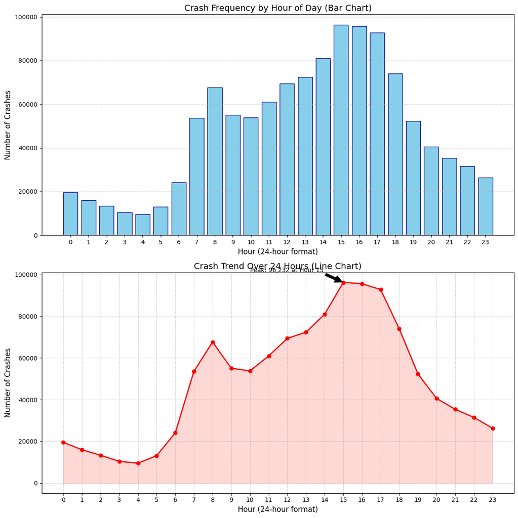

```python
crash_hour_count = final_merged['CRASH_HOUR'].value_counts().sort_index()
print(crash_hour_count)


# Data provided for CRASH_HOUR
crash_hour_count = {
    "Hour": list(range(24)),
    "Crash_Count": [
        19556, 15984, 13345, 10388, 9537, 13094, 24073, 53599,
        67699, 55089, 53787, 60958, 69376, 72379, 80952, 96232,
        95651, 92816, 73989, 52340, 40599, 35365, 31489, 26310
    ]
}

df_hourly = pd.DataFrame(crash_hour_count)

# Create a figure with two subplots: Bar Chart and Line Chart
fig, (ax1, ax2) = plt.subplots(2, 1, figsize=(12, 12))

# Subplot 1: Bar Chart
ax1.bar(df_hourly['Hour'], df_hourly['Crash_Count'], color='skyblue', edgecolor='navy')
ax1.set_title('Crash Frequency by Hour of Day (Bar Chart)', fontsize=14)
ax1.set_xlabel('Hour (24-hour format)', fontsize=12)
ax1.set_ylabel('Number of Crashes', fontsize=12)
ax1.set_xticks(range(24))
ax1.grid(axis='y', linestyle='--', alpha=0.6)

# Subplot 2: Line Chart (Time Series)
ax2.plot(df_hourly['Hour'], df_hourly['Crash_Count'], marker='o', linestyle='-', color='red', linewidth=2)
ax2.fill_between(df_hourly['Hour'], df_hourly['Crash_Count'], color='salmon', alpha=0.3)
ax2.set_title('Crash Trend Over 24 Hours (Line Chart)', fontsize=14)
ax2.set_xlabel('Hour (24-hour format)', fontsize=12)
ax2.set_ylabel('Number of Crashes', fontsize=12)
ax2.set_xticks(range(24))
ax2.grid(True, linestyle='--', alpha=0.6)

# Annotate peaks
peak_hour = df_hourly.loc[df_hourly['Crash_Count'].idxmax(), 'Hour']
peak_val = df_hourly['Crash_Count'].max()
ax2.annotate(f'Peak: {peak_val:,} at Hour {peak_hour}', xy=(peak_hour, peak_val), xytext=(peak_hour-5, peak_val+5000),
             arrowprops=dict(facecolor='black', shrink=0.05), fontsize=10)

plt.tight_layout()
plt.savefig('crash_hourly_analysis.png')

print("Hourly distribution plots generated.")
```

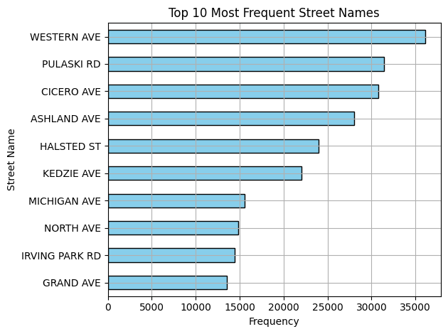

```python
# Returns a Street Name and number of crash
# Get the top 10 most frequent streets
top_streets = final_merged['STREET_NAME'].value_counts().head(10)

# Create the plot
top_streets.plot(kind='barh', color='skyblue', edgecolor='black')

# Add labels and title
plt.title('Top 10 Most Frequent Street Names')
plt.xlabel('Frequency')
plt.ylabel('Street Name')
plt.gca().invert_yaxis()
plt.grid(True)
plt.tight_layout()
plt.show()
```

[figure not shown]

```python
# Returns a primary contributor cause number of crash
# Get the top 10 most frequent causes

prim_contributory_cause = final_merged['PRIM_CONTRIBUTORY_CAUSE'].value_counts().head(20)

# Create the plot
prim_contributory_cause.plot(kind='barh', color='skyblue', edgecolor='black')

# Add labels and title
plt.title('Top 10 Most Frequent Primary Contributory Cause')
plt.xlabel('Frequency')
plt.ylabel('PRIM CONTRIBUTORY CAUSE')

# Invert the y-axis so the highest count is at the top
plt.gca().invert_yaxis()

# Display the plot
plt.grid(True)
plt.show()
```

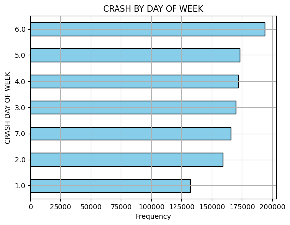

```python
# Returns CRASH BY DAY OF WEEK

crash_day = final_merged['CRASH_DAY_OF_WEEK'].value_counts().head(20)

# Create the plot
crash_day.plot(kind='barh', color='skyblue', edgecolor='black')

# Add labels and title
plt.title('CRASH BY DAY OF WEEK')
plt.xlabel('Frequency')
plt.ylabel('CRASH DAY OF WEEK')

# Invert the y-axis so the highest count is at the top
plt.gca().invert_yaxis()

# Display the plot
plt.grid(True)
plt.show()
```

ONE-HOT ENCODING SEVERAL CATEGORICAL COLUMNS

```python
# List of columns to encode
cols_to_encode = ['WEATHER_CONDITION', 'LIGHTING_CONDITION', 'DRIVER_ACTION', 'DRIVER_VISION', 'PRIM_CONTRIBUTORY_CAUSE', 'ROADWAY_SURFACE_COND']

# Initialize the encoder
encoder = OneHotEncoder(handle_unknown='ignore', sparse_output=True)

# Fit and transform the categorical columns
encoded_data = encoder.fit_transform(final_merged[cols_to_encode])

# This creates a sparse matrix that is much lighter on memory
print(type(encoded_data))
# Perform One-Hot Encoding
#drop_first=True helps avoid the "Dummy Variable Trap" (multicollinearity)
df_encoded = pd.get_dummies(final_merged, columns=cols_to_encode, drop_first=True, dtype=int)

# Display the first few rows of the new columns
print(df_encoded.head())
```

```
<class 'scipy.sparse._csr.csr_matrix'>
  PERSON_ID          CRASH_DATE         CITY SEX   AGE  SAFETY_EQUIPMENT  \
0  O2267595 2026-03-19 00:25:00      CHICAGO   M  21.0     USAGE UNKNOWN
2  O2267593 2026-03-18 23:50:00      CHICAGO   F  52.0     USAGE UNKNOWN
3  O2267594 2026-03-18 23:50:00      CHICAGO   M  40.0  SAFETY BELT USED
4  O2267581 2026-03-18 23:20:00      CHICAGO   M  32.0  SAFETY BELT USED
6  O2267556 2026-03-18 21:12:00  BOLINGBROOK   M  25.0     USAGE UNKNOWN

    MAKE  VEHICLE_YEAR VEHICLE_TYPE VEHICLE_USE  ...  \
0  HONDA        2024.0    PASSENGER    PERSONAL  ...
2    KIA        2019.0    PASSENGER    PERSONAL  ...
3   FORD        2020.0        OTHER      POLICE  ...
4   FORD        2020.0    PASSENGER      POLICE  ...
6   AUDI        2016.0    PASSENGER    PERSONAL  ...

```

[output cut: 50 more lines]

```python
df_encoded.info()
df_encoded.head()
```

```
<class 'pandas.core.frame.DataFrame'>
Index: 1164607 entries, 0 to 2282950
Columns: 119 entries, PERSON_ID to ROADWAY_SURFACE_COND_WET
dtypes: datetime64[ns](2), float64(7), int64(93), object(17)
memory usage: 1.0+ GB
```

|  | PERSON_ID | CRASH_DATE | CITY | SEX | AGE | SAFETY_EQUIPMENT | MAKE | VEHICLE_YEAR | VEHICLE_TYPE | VEHICLE_USE | ... | PRIM_CONTRIBUTORY_CAUSE_UNABLE TO DETERMINE | PRIM_CONTRIBUTORY_CAUSE_UNDER THE INFLUENCE OF ALCOHOL/DRUGS (USE WHEN ARREST IS EFFECTED) | PRIM_CONTRIBUTORY_CAUSE_VISION OBSCURED (SIGNS, TREE LIMBS, BUILDINGS, ETC.) | PRIM_CONTRIBUTORY_CAUSE_WEATHER | ROADWAY_SURFACE_COND_ICE | ROADWAY_SURFACE_COND_OTHER | ROADWAY_SURFACE_COND_SAND, MUD, DIRT | ROADWAY_SURFACE_COND_SNOW OR SLUSH | ROADWAY_SURFACE_COND_UNKNOWN | ROADWAY_SURFACE_COND_WET |
| --- | --- | --- | --- | --- | --- | --- | --- | --- | --- | --- | --- | --- | --- | --- | --- | --- | --- | --- | --- | --- | --- |
| 0 | O2267595 | 2026-03-19 00:25:00 | CHICAGO | M | 21.0 | USAGE UNKNOWN | HONDA | 2024.0 | PASSENGER | PERSONAL | ... | 0 | 0 | 0 | 0 | 0 | 0 | 0 | 0 | 0 | 0 |
| 2 | O2267593 | 2026-03-18 23:50:00 | CHICAGO | F | 52.0 | USAGE UNKNOWN | KIA | 2019.0 | PASSENGER | PERSONAL | ... | 0 | 0 | 0 | 0 | 0 | 0 | 0 | 0 | 0 | 0 |
| 3 | O2267594 | 2026-03-18 23:50:00 | CHICAGO | M | 40.0 | SAFETY BELT USED | FORD | 2020.0 | OTHER | POLICE | ... | 0 | 0 | 0 | 0 | 0 | 0 | 0 | 0 | 0 | 0 |
| 4 | O2267581 | 2026-03-18 23:20:00 | CHICAGO | M | 32.0 | SAFETY BELT USED | FORD | 2020.0 | PASSENGER | POLICE | ... | 1 | 0 | 0 | 0 | 0 | 0 | 0 | 0 | 0 | 0 |
| 6 | O2267556 | 2026-03-18 21:12:00 | BOLINGBROOK | M | 25.0 | USAGE UNKNOWN | AUDI | 2016.0 | PASSENGER | PERSONAL | ... | 0 | 0 | 0 | 0 | 0 | 0 | 0 | 0 | 0 | 0 |

5 rows × 119 columns

```python
# Checking all columns
for i, col in enumerate(df_encoded.columns):
    print(f"{i}: {col}")
```

```
0: PERSON_ID
1: CRASH_DATE
2: CITY
3: SEX
4: AGE
5: SAFETY_EQUIPMENT
6: MAKE
7: VEHICLE_YEAR
8: VEHICLE_TYPE
9: VEHICLE_USE
10: MANEUVER
11: POSTED_SPEED_LIMIT
12: TRAFFIC_CONTROL_DEVICE
13: DEVICE_CONDITION
14: FIRST_CRASH_TYPE
```

[output cut: 104 more lines]

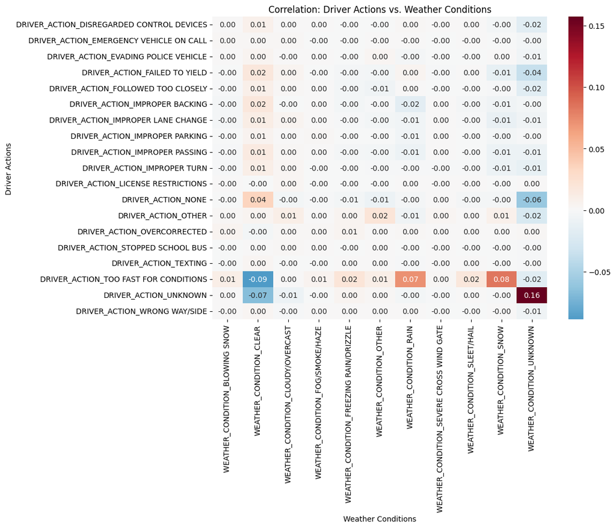

```python
# Identify encoded columns for the two categories
action_cols = [col for col in df_encoded.columns if 'DRIVER_ACTION' in col]
weather_cols = [col for col in df_encoded.columns if 'WEATHER_CONDITION' in col]

# Compute correlation for only those columns
corr_subset = df_encoded[action_cols + weather_cols].corr()

# Filter the matrix to show only Cross-Correlation (Action vs. Weather)
cross_corr = corr_subset.loc[action_cols, weather_cols]

# Plot Heatmap
plt.figure(figsize=(12, 10))
sns.heatmap(cross_corr, annot=True, cmap='RdBu_r', center=0, fmt=".2f")
plt.title('Correlation: Driver Actions vs. Weather Conditions')
plt.xlabel('Weather Conditions')
plt.ylabel('Driver Actions')
plt.tight_layout()
plt.savefig('driver_action_weather_corr.png')
```

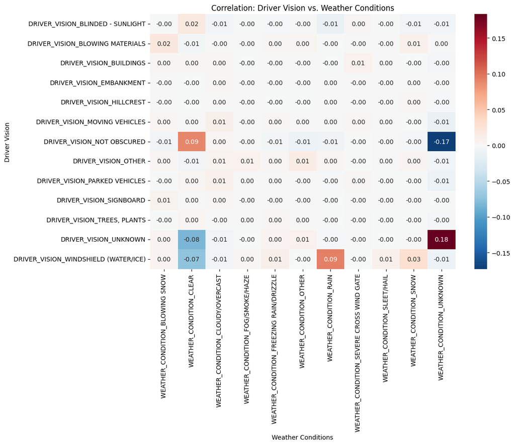

```python
# Identify encoded columns for the two categories
driver_vision = [col for col in df_encoded.columns if 'DRIVER_VISION' in col]
weather_cols = [col for col in df_encoded.columns if 'WEATHER_CONDITION' in col]

# Compute correlation for only those columns
corr_subset = df_encoded[driver_vision + weather_cols].corr()

# Filter the matrix to show only Cross-Correlation (Action vs. Weather)
cross_corr = corr_subset.loc[driver_vision, weather_cols]

# Plot Heatmap
plt.figure(figsize=(12, 10))
sns.heatmap(cross_corr, annot=True, cmap='RdBu_r', center=0, fmt=".2f")
plt.title('Correlation: Driver Vision vs. Weather Conditions')
plt.xlabel('Weather Conditions')
plt.ylabel('Driver Vision')
plt.tight_layout()
plt.savefig('driver_vision_weather_corr.png')
```

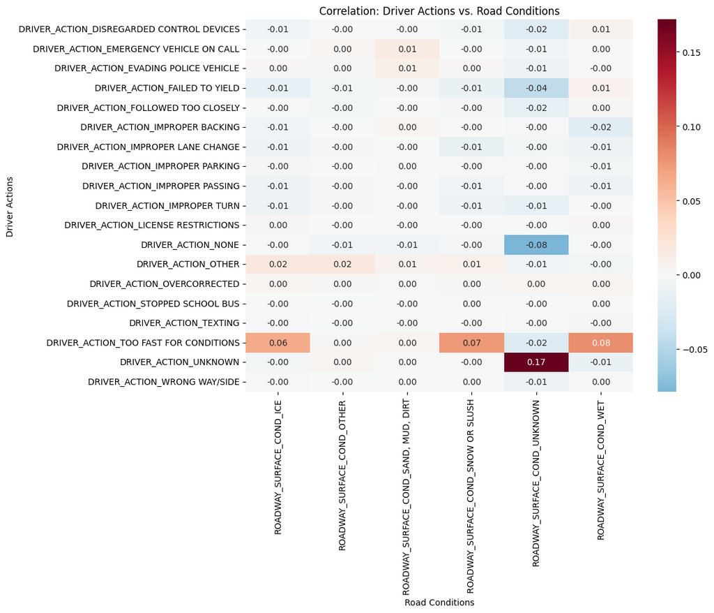

```python
# Identify encoded columns for the two categories
action_cols = [col for col in df_encoded.columns if 'DRIVER_ACTION' in col]
road_cond = [col for col in df_encoded.columns if 'ROADWAY_SURFACE_COND' in col]

# Compute correlation for only those columns
corr_subset = df_encoded[action_cols + road_cond].corr()

# Filter the matrix to show only Cross-Correlation (Action vs. Road Surface)
cross_corr = corr_subset.loc[action_cols, road_cond]

# Plot Heatmap
plt.figure(figsize=(12, 10))
sns.heatmap(cross_corr, annot=True, cmap='RdBu_r', center=0, fmt=".2f")
plt.title('Correlation: Driver Actions vs. Road Conditions')
plt.xlabel('Road Conditions')
plt.ylabel('Driver Actions')
plt.tight_layout()
plt.savefig('driver_action_road_cond_corr.png')
```

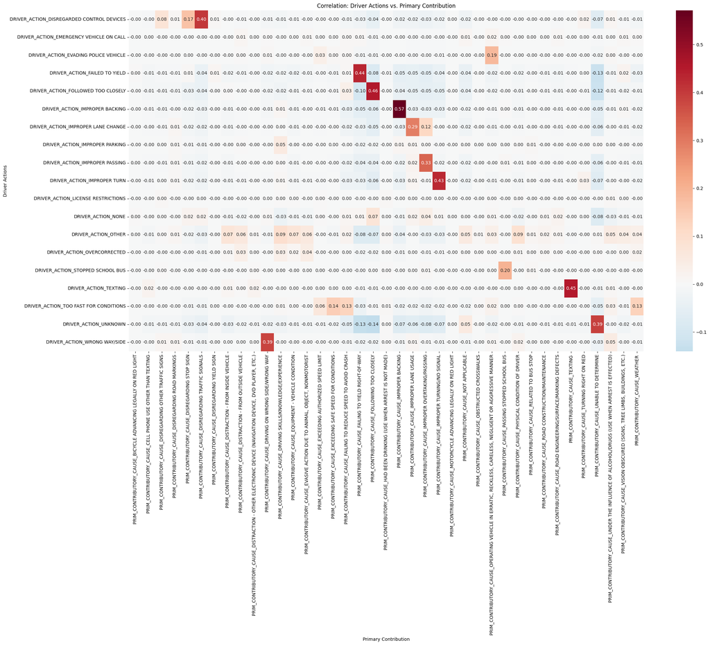

```python
# Identify encoded columns for the two categories
action_cols = [col for col in df_encoded.columns if 'DRIVER_ACTION' in col]
prim_contributory_cause = [col for col in df_encoded.columns if 'PRIM_CONTRIBUTORY_CAUSE' in col]

# Compute correlation for only those columns
corr_subset = df_encoded[action_cols + prim_contributory_cause].corr()

# Filter the matrix to show only Cross-Correlation (Action vs. Primary Cont)
cross_corr = corr_subset.loc[action_cols, prim_contributory_cause]

# Plot Heatmap
plt.figure(figsize=(24, 20))
sns.heatmap(cross_corr, annot=True, cmap='RdBu_r', center=0, fmt=".2f")
plt.title('Correlation: Driver Actions vs. Primary Contribution')
plt.xlabel('Primary Contribution')
plt.ylabel('Driver Actions')
plt.tight_layout()
plt.savefig('driver_action_primary_cont_corr.png')
```

**MODELING, FEATURE ENGINEERING AND PERFORMING MULTIPLE CLASSIFICATION**

```python
# Find columns that are strings/objects
object_cols = df_encoded.select_dtypes(include=['object']).columns
print("String columns that will break the model:", object_cols.tolist())
```

```
String columns that will break the model: ['PERSON_ID', 'CITY', 'SEX', 'SAFETY_EQUIPMENT', 'MAKE', 'VEHICLE_TYPE', 'VEHICLE_USE', 'MANEUVER', 'TRAFFIC_CONTROL_DEVICE', 'DEVICE_CONDITION', 'FIRST_CRASH_TYPE', 'TRAFFICWAY_TYPE', 'ALIGNMENT', 'ROAD_DEFECT', 'REPORT_TYPE', 'STREET_DIRECTION', 'STREET_NA…
```

```python
# Grouping
# Define the mapping dictionary
cause_mapping = {
    # Group: Aggressive Driving
    'FAILING TO YIELD RIGHT-OF-WAY': 'Aggressive/Illegal Driving',
    'FOLLOWING TOO CLOSELY': 'Aggressive/Illegal Driving',
    'IMPROPER OVERTAKING/PASSING': 'Aggressive/Illegal Driving',
    'EXCEEDING AUTHORIZED SPEED LIMIT': 'Aggressive/Illegal Driving',
    'EXCEEDING SAFE SPEED FOR CONDITIONS': 'Aggressive/Illegal Driving',
    'DISREGARDING TRAFFIC SIGNALS': 'Aggressive/Illegal Driving',
    'DISREGARDING STOP SIGN': 'Aggressive/Illegal Driving',
    'OPERATING VEHICLE IN ERRATIC, RECKLESS, CARELESS, NEGLIGENT OR AGGRESSIVE MANNER': 'Aggressive/Illegal Driving',

    # Group: Error/Inexperience
    'DRIVING SKILLS/KNOWLEDGE/EXPERIENCE': 'Driver Error',
    'IMPROPER BACKING': 'Driver Error',
    'IMPROPER LANE USAGE': 'Driver Error',
    'IMPROPER TURNING/NO SIGNAL': 'Driver Error',
    'FAILING TO REDUCE SPEED TO AVOID CRASH': 'Driver Error',

    # Group: Distraction & Impairment
    'DISTRACTION - FROM INSIDE VEHICLE': 'Distraction/Impairment',
    'DISTRACTION - FROM OUTSIDE VEHICLE': 'Distraction/Impairment',
    'CELL PHONE USE OTHER THAN TEXTING': 'Distraction/Impairment',
    'TEXTING': 'Distraction/Impairment',
    'UNDER THE INFLUENCE OF ALCOHOL/DRUGS (USE WHEN ARREST IS EFFECTED)': 'Distraction/Impairment',
    'HAD BEEN DRINKING (USE WHEN ARREST IS NOT MADE)': 'Distraction/Impairment',
    'PHYSICAL CONDITION OF DRIVER': 'Distraction/Impairment',

    # Group: Infrastructure & Environment
    'WEATHER': 'Environment/Vehicle',
    'ROAD CONSTRUCTION/MAINTENANCE': 'Environment/Vehicle',
    'ROAD ENGINEERING/SURFACE/MARKING DEFECTS': 'Environment/Vehicle',
    'EQUIPMENT - VEHICLE CONDITION': 'Environment/Vehicle',
    'VISION OBSCURED (SIGNS, TREE LIMBS, BUILDINGS, ETC.)': 'Environment/Vehicle',
    'ANIMAL': 'Environment/Vehicle',

    # Group: Unknown/Other
    'UNABLE TO DETERMINE': 'Unknown/Other',
    'NOT APPLICABLE': 'Unknown/Other'
}

# Apply the mapping
final_merged['CAUSE_GROUP'] = final_merged['PRIM_CONTRIBUTORY_CAUSE'].map(cause_mapping).fillna('Unknown/Other')
```

**MODELING USING PRIM CONTRIBUTORY CAUSE**

```python
# 1. Prepare Features (X) and Target (y)
y = final_merged['CAUSE_GROUP']

# Drop the target and any columns that are "cheating" (leakage)
# Also drop the string columns we identified earlier
cols_to_drop = list(object_cols) + ['DRIVER_ACTION', 'DRIVER_VISION', 'CRASH_DATE', 'DATE_POLICE_NOTIFIED']
leakage_and_strings = [col for col in df_encoded.columns if 'CAUSE' in col or 'WEATHER' in col or 'SURFACE' in col]
X = df_encoded.drop(columns=leakage_and_strings + cols_to_drop + object_cols.tolist(), errors='ignore')


# 2. Split the data (80% training, 20% testing)
X_train, X_test, y_train, y_test = train_test_split(X, y, test_size=0.2, random_state=42, stratify=y)

# 3. Initialize and Train
# We use 'balanced' to help the model see the smaller groups (like Distraction)
model = RandomForestClassifier(
    n_estimators=100,
    max_depth=12,
    class_weight='balanced',
    random_state=42,
    n_jobs=-1
)
model.fit(X_train, y_train)

# 4. Evaluate
y_pred = model.predict(X_test)
print(classification_report(y_test, y_pred))
```

```
                            precision    recall  f1-score   support

Aggressive/Illegal Driving       0.54      0.71      0.61     87228
    Distraction/Impairment       0.09      0.43      0.15      6212
              Driver Error       0.59      0.27      0.37     46376
       Environment/Vehicle       0.13      0.42      0.19      8319
             Unknown/Other       0.77      0.37      0.50     84787

                  accuracy                           0.48    232922
                 macro avg       0.42      0.44      0.36    232922
              weighted avg       0.61      0.48      0.49    232922
```

**MODELING USING CRASH HOUR**

```python
# 1. Prepare Features (X) and Target (y)
y = final_merged['CRASH_HOUR']

# Drop the target and any columns that are "cheating" (leakage)
# Also drop the string columns we identified earlier
cols_to_drop = list(object_cols) + ['DRIVER_ACTION', 'DRIVER_VISION', 'CRASH_DATE', 'DATE_POLICE_NOTIFIED']
leakage_and_strings = [col for col in df_encoded.columns if 'CAUSE' in col or 'WEATHER' in col or 'SURFACE' in col]
X = df_encoded.drop(columns=leakage_and_strings + cols_to_drop + object_cols.tolist(), errors='ignore')


# 2. Split the data (80% training, 20% testing)
X_train, X_test, y_train, y_test = train_test_split(X, y, test_size=0.2, random_state=42, stratify=y)

# 3. Initialize and Train
# We use 'balanced' to help the model see the smaller groups (like Distraction)
model = RandomForestClassifier(
    n_estimators=100,
    max_depth=12,
    class_weight='balanced',
    random_state=42,
    n_jobs=-1
)
model.fit(X_train, y_train)

# 4. Evaluate
y_pred = model.predict(X_test)
print(classification_report(y_test, y_pred))
```

```
              precision    recall  f1-score   support

         0.0       1.00      0.99      1.00      3911
         1.0       0.97      0.96      0.97      3197
         2.0       0.90      0.93      0.92      2669
         3.0       0.42      0.93      0.58      2078
         4.0       0.50      0.79      0.61      1907
         5.0       0.55      0.43      0.48      2619
         6.0       0.33      0.25      0.29      4815
         7.0       0.77      0.89      0.82     10720
         8.0       0.97      0.95      0.96     13540
         9.0       0.96      0.97      0.97     11018
        10.0       0.92      0.97      0.95     10757
        11.0       1.00      0.98      0.99     12192
        12.0       1.00      0.98      0.99     13875
        13.0       0.93      0.98      0.95     14476
        14.0       0.86      0.98      0.92     16190
        15.0       0.79      0.93      0.85     19246
        16.0       0.81      0.78      0.80     19130
        17.0       0.92      0.70      0.79     18563
        18.0       0.92      0.43      0.59     14798
        19.0       0.88      0.39      0.54     10468
        20.0       0.41      0.75      0.53      8120
        21.0       0.69      0.89      0.78      7073
        22.0       1.00      0.97      0.98      6298
        23.0       1.00      1.00      1.00      5262

    accuracy                           0.83    232922
   macro avg       0.81      0.83      0.80    232922
weighted avg       0.86      0.83      0.83    232922
```

**MODELING USING CRASH MONTH**

```python
# 1. Prepare Features (X) and Target (y)
y = final_merged['CRASH_MONTH']

# Drop the target and any columns that are "cheating" (leakage)
# Also drop the string columns we identified earlier
cols_to_drop = list(object_cols) + ['DRIVER_ACTION', 'DRIVER_VISION', 'CRASH_DATE', 'DATE_POLICE_NOTIFIED']
leakage_and_strings = [col for col in df_encoded.columns if 'CAUSE' in col or 'WEATHER' in col or 'SURFACE' in col]
X = df_encoded.drop(columns=leakage_and_strings + cols_to_drop + object_cols.tolist(), errors='ignore')


# 2. Split the data (80% training, 20% testing)
X_train, X_test, y_train, y_test = train_test_split(X, y, test_size=0.2, random_state=42, stratify=y)

# 3. Initialize and Train
# We use 'balanced' to help the model see the smaller groups (like Distraction)
model = RandomForestClassifier(
    n_estimators=100,
    max_depth=12,
    class_weight='balanced',
    random_state=42,
    n_jobs=-1
)
model.fit(X_train, y_train)

# 4. Evaluate
y_pred = model.predict(X_test)
print(classification_report(y_test, y_pred))
```

```
              precision    recall  f1-score   support

         1.0       1.00      0.99      1.00     18983
         2.0       0.93      0.98      0.95     18053
         3.0       0.96      0.98      0.97     18252
         4.0       0.99      0.95      0.97     16873
         5.0       1.00      0.97      0.98     19656
         6.0       1.00      1.00      1.00     19420
         7.0       1.00      0.99      0.99     19517
         8.0       0.97      0.97      0.97     20185
         9.0       0.97      0.93      0.95     20460
        10.0       0.92      0.96      0.94     21666
        11.0       0.95      0.95      0.95     19716
        12.0       1.00      1.00      1.00     20141

    accuracy                           0.97    232922
   macro avg       0.97      0.97      0.97    232922
weighted avg       0.97      0.97      0.97    232922
```

**PLOTTING A CLASSIFICATION REPORT FOR PRIM CONTRIBUTORY CAUSE**

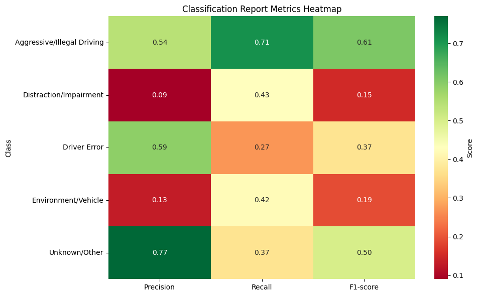

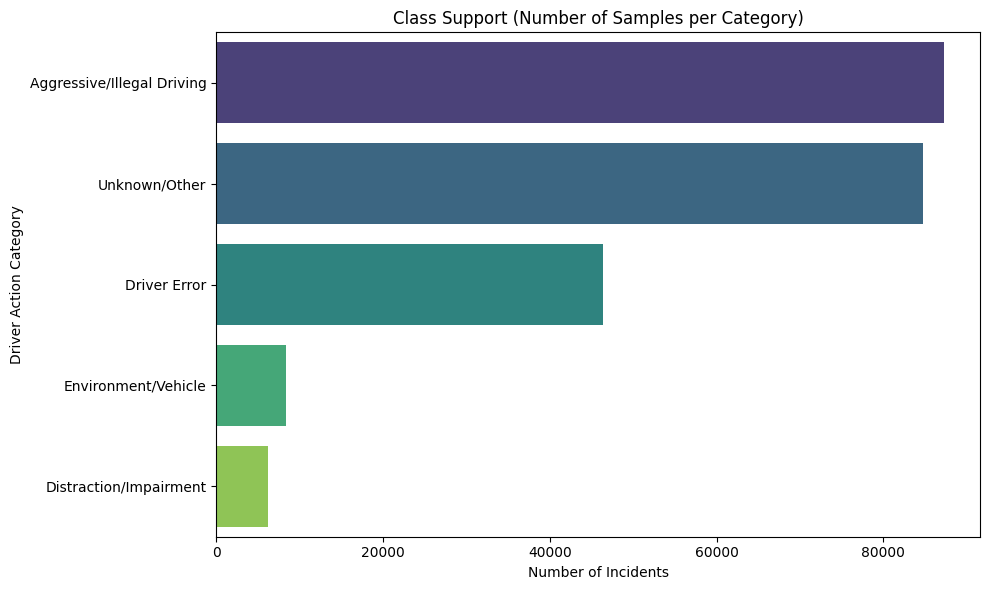

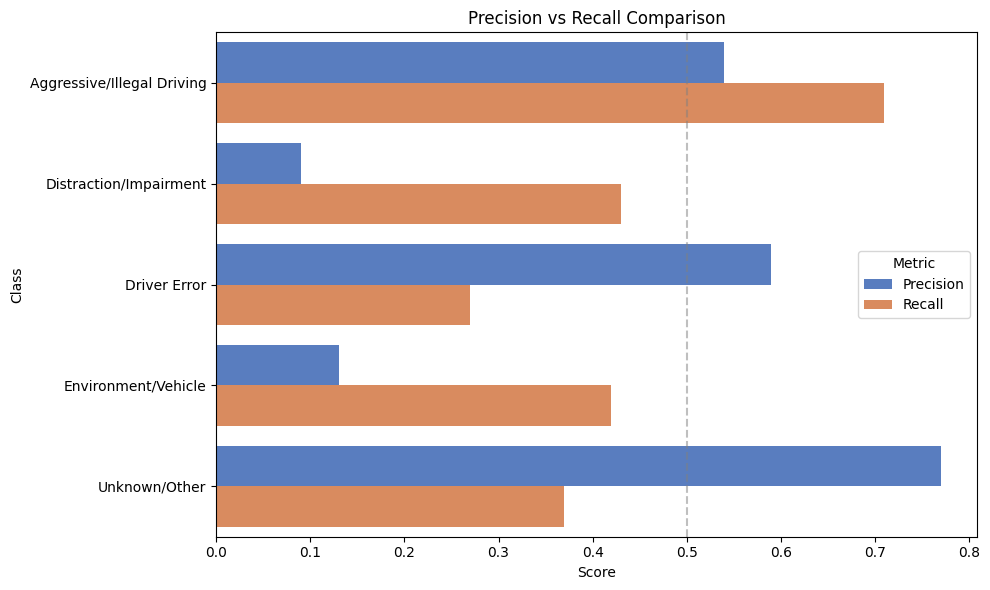

```python
# Data from the classification report
data = {
    'Class': [
        'Aggressive/Illegal Driving',
        'Distraction/Impairment',
        'Driver Error',
        'Environment/Vehicle',
        'Unknown/Other'
    ],
    'Precision': [0.54, 0.09, 0.59, 0.13, 0.77],
    'Recall': [0.71, 0.43, 0.27, 0.42, 0.37],
    'F1-score': [0.61, 0.15, 0.37, 0.19, 0.50],
    'Support': [87228, 6212, 46376, 8319, 84787]
}

df_metrics = pd.DataFrame(data)

# 1. Heatmap for Precision, Recall, F1-score
plt.figure(figsize=(10, 6))
heatmap_data = df_metrics.set_index('Class')[['Precision', 'Recall', 'F1-score']]
sns.heatmap(heatmap_data, annot=True, cmap='RdYlGn', fmt='.2f', cbar_kws={'label': 'Score'})
plt.title('Classification Report Metrics Heatmap')
plt.tight_layout()
plt.savefig('classification_heatmap.png')

# 2. Bar chart for Support (Class Imbalance)
plt.figure(figsize=(10, 6))
sns.barplot(data=df_metrics.sort_values('Support', ascending=False), x='Support', y='Class', palette='viridis')
plt.title('Class Support (Number of Samples per Category)')
plt.xlabel('Number of Incidents')
plt.ylabel('Driver Action Category')
plt.tight_layout()
plt.savefig('class_support_bar.png')

# 3. Precision vs Recall Comparison
df_melted = df_metrics.melt(id_vars='Class', value_vars=['Precision', 'Recall'], var_name='Metric', value_name='Score')
plt.figure(figsize=(10, 6))
sns.barplot(data=df_melted, x='Score', y='Class', hue='Metric', palette='muted')
plt.title('Precision vs Recall Comparison')
plt.axvline(0.5, color='gray', linestyle='--', alpha=0.5)
plt.tight_layout()
plt.savefig('precision_recall_comparison.png')
```

To "plot this" classification report, I have visualized the three critical dimensions of your model's performance: the Metric Heatmap, the Class Imbalance, and the Precision-Recall Conflict.

**1. Classification Report Heatmap** This heatmap provides a visual "report card." The warmer colors (Green) indicate where the model is succeeding, while the cooler/red colors indicate where it is failing. Success: Aggressive/Illegal Driving and Unknown/Other show the strongest performance overall. Failure: Distraction/Impairment and Environment/Vehicle are clearly lagging, showing low precision and F1-scores

**3. Precision vs. Recall Comparison** This plot highlights the "logic" of your model. High Precision / Low Recall (Driver Error, Unknown): For these classes, the model is very conservative. It doesn't guess "Driver Error" often, but when it does, it's usually right (0.59-0.77 precision). Low Precision / High Recall (Distraction, Environment): For these, the model is "over-guessing." It captures about 43% of the actual incidents, but it's wrong nearly 90% of the time it makes that prediction.

**OBSERVATIONS**

Based on my findings, here are some interesting analyses:

**Crash Causes**: A breakdown of the PRIM_CONTRIBUTORY_CAUSE and DRIVER_ACTION shoews taht driver actions is the main contributor for car accidents. Drivers failing to yield right-of-way has over 150,000 incidences, followed closely by divers following too closely.

**Temporal Trends:** An analysis by CRASH_HOUR, CRASH_DAY_OF_WEEK, and CRASH_MONTH reaveal an interestign pattern.

**RECOMMENDATIONS AND NEXT STEPS**

Therefore, the authorities of the city of Chicago can do the following to avert car accidents.

**1.Installation of CCTV cameras on strategic intersections for recording of incidences and deterring motorists from breaking traffic rules.**

**2.The city of Chicago authoroties has to enforce and penalize offenders to discourage breaking rules on the road.**

**4.Public sensitication on road safety and traffic laws**